# examples_0112

## Pattern 1

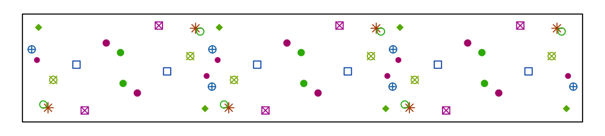

Match the IUC name:

## Pattern 2

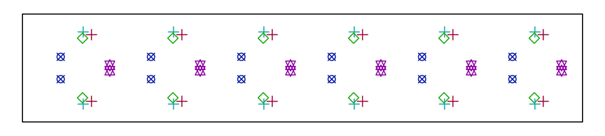

Match the Conway nickname:

- The first pattern is a p2 (which is also called spinning hop).
- The second pattern is a jump (which is also called p11m).

Let's say you want to make a [spirolateral](https://en.wikipedia.org/wiki/Spirolateral).

If the turn angle is $12^{\circ}$ and the maximum segment length is $19$, then which [spirolateral](https://en.wikipedia.org/wiki/Spirolateral) is created?

You can use this tool:

https://artockthedino.github.io/pbl/spirolateral/spirolateral_generator.html

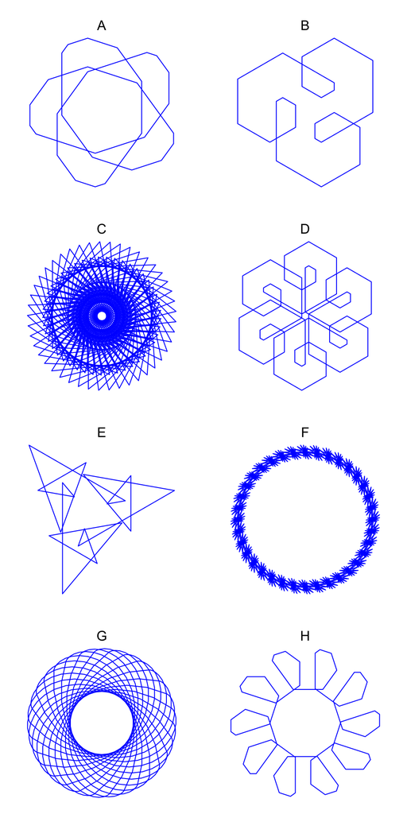

ABCDEFGH

The correct answer is G.

Below I've listed the parameters used to generate all patterns:

- A:
  - Turn angle = 36
  - Count max = 6

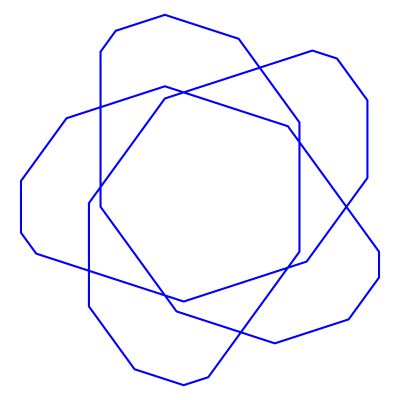

- B:
  - Turn angle = 60
  - Count max = 8

[figure not shown]

- C:
  - Turn angle = 128
  - Count max = 7

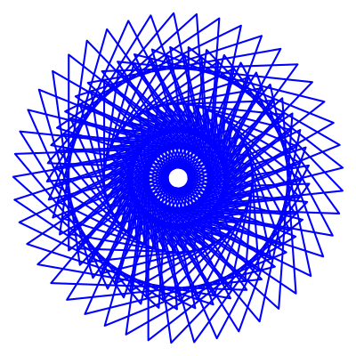

- D:
  - Turn angle = 60
  - Count max = 11

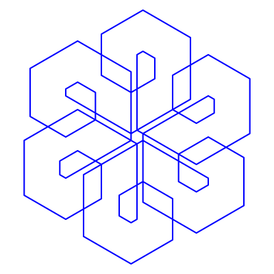

- E:
  - Turn angle = 140
  - Count max = 6

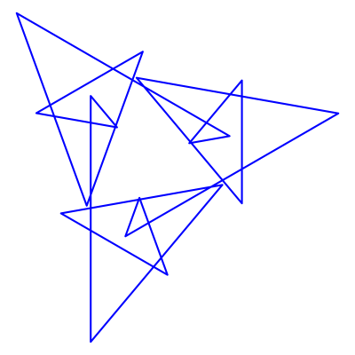

- F:
  - Turn angle = 170
  - Count max = 19

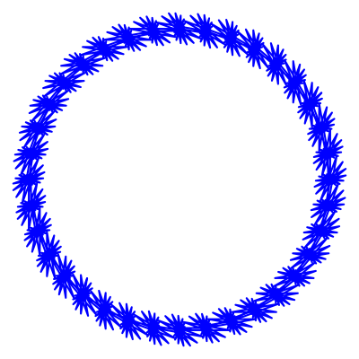

- G:
  - Turn angle = 12
  - Count max = 19

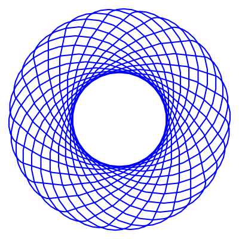

- H:
  - Turn angle = 54
  - Count max = 6

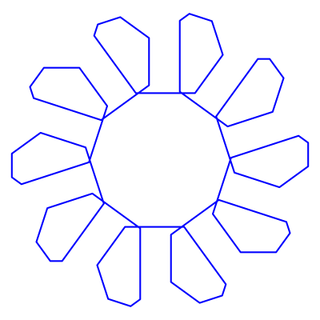

Let's say you want to make a [spirolateral](https://en.wikipedia.org/wiki/Spirolateral).

If the turn angle is $126^{\circ}$ and the maximum segment length is $14$, then which [spirolateral](https://en.wikipedia.org/wiki/Spirolateral) is created?

You can use this tool:

https://artockthedino.github.io/pbl/spirolateral/spirolateral_generator.html

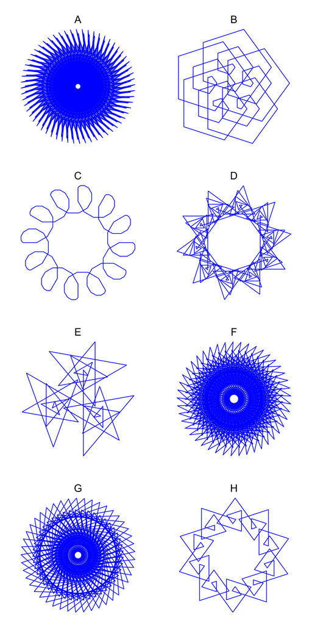

ABCDEFGH

The correct answer is D.

Below I've listed the parameters used to generate all patterns:

- A:
  - Turn angle = 174
  - Count max = 13

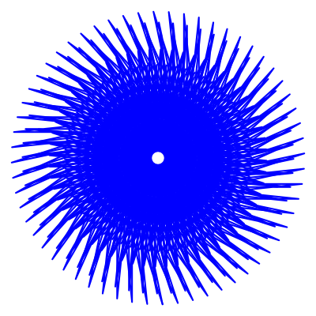

- B:
  - Turn angle = 72
  - Count max = 12

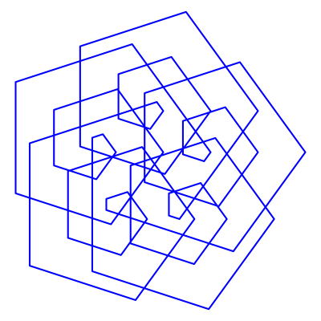

- C:
  - Turn angle = 30
  - Count max = 11

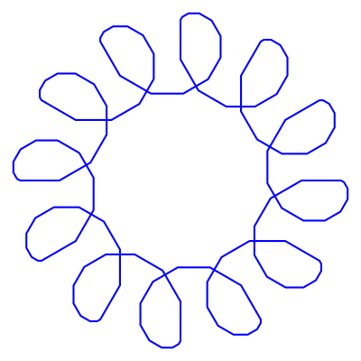

- D:
  - Turn angle = 126
  - Count max = 14

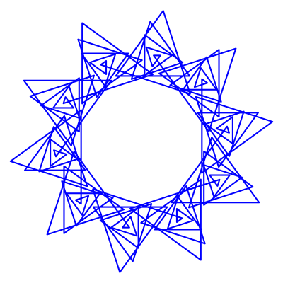

- E:
  - Turn angle = 140
  - Count max = 12

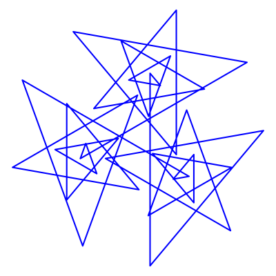

- F:
  - Turn angle = 152
  - Count max = 11

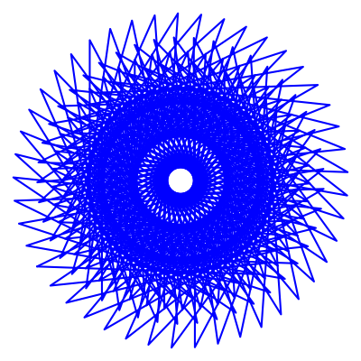

- G:
  - Turn angle = 128
  - Count max = 7

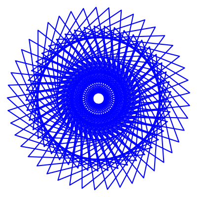

- H:
  - Turn angle = 108
  - Count max = 7

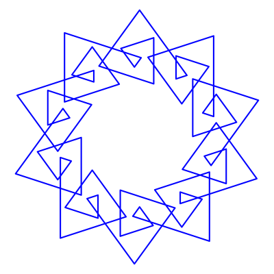

Let's say you want to make a [spirolateral](https://en.wikipedia.org/wiki/Spirolateral).

If the turn angle is $27^{\circ}$ and the maximum segment length is $18$, then which [spirolateral](https://en.wikipedia.org/wiki/Spirolateral) is created?

You can use this tool:

https://artockthedino.github.io/pbl/spirolateral/spirolateral_generator.html

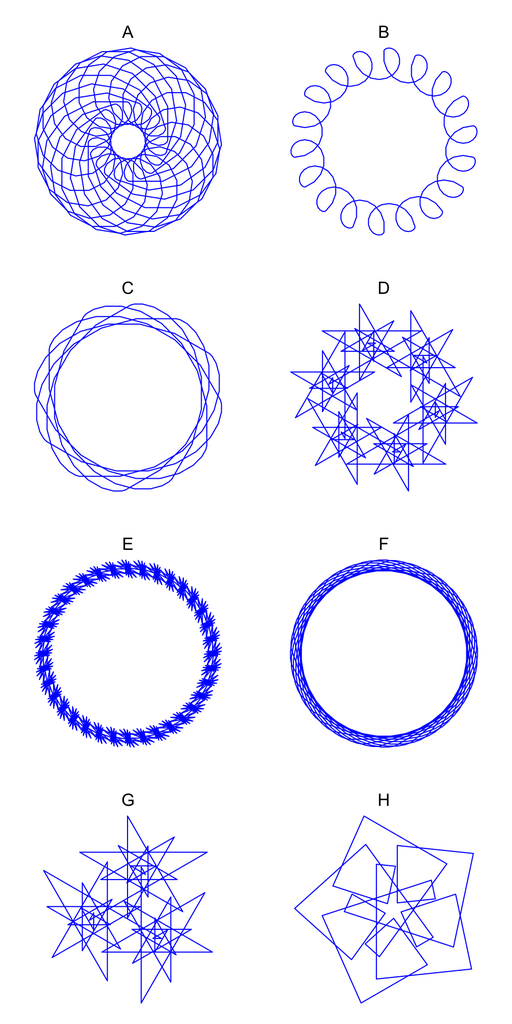

ABCDEFGH

The correct answer is A.

Below I've listed the parameters used to generate all patterns:

- A:
  - Turn angle = 27
  - Count max = 18

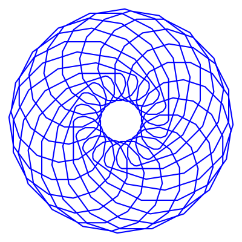

- B:
  - Turn angle = 20
  - Count max = 17

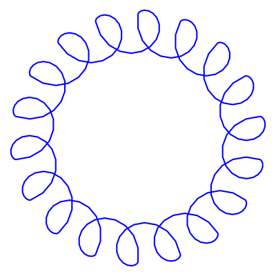

- C:
  - Turn angle = 15
  - Count max = 10

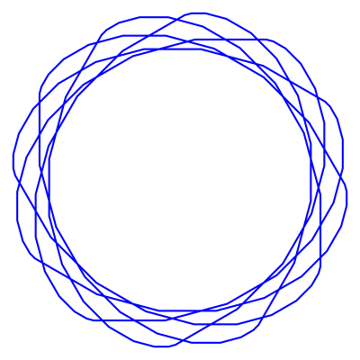

- D:
  - Turn angle = 150
  - Count max = 14

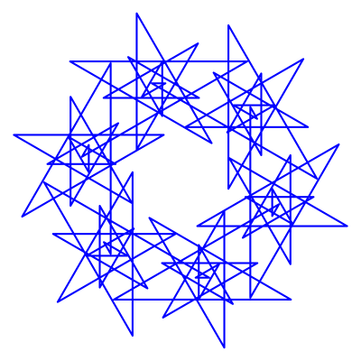

- E:
  - Turn angle = 170
  - Count max = 17

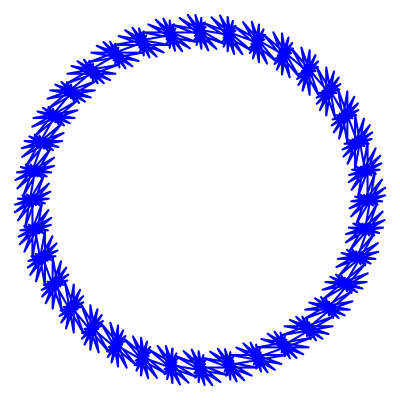

- F:
  - Turn angle = 10
  - Count max = 11

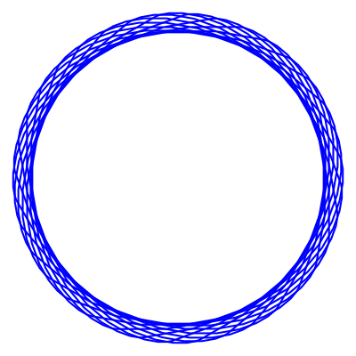

- G:
  - Turn angle = 150
  - Count max = 16

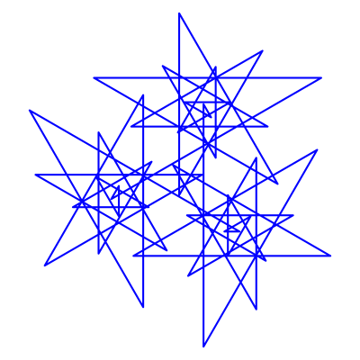

- H:
  - Turn angle = 96
  - Count max = 6

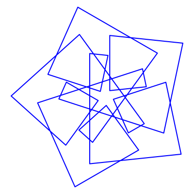

Let's say you want to make a [spirolateral](https://en.wikipedia.org/wiki/Spirolateral).

If the turn angle is $30^{\circ}$ and the maximum segment length is $15$, then which [spirolateral](https://en.wikipedia.org/wiki/Spirolateral) is created?

You can use this tool:

https://artockthedino.github.io/pbl/spirolateral/spirolateral_generator.html

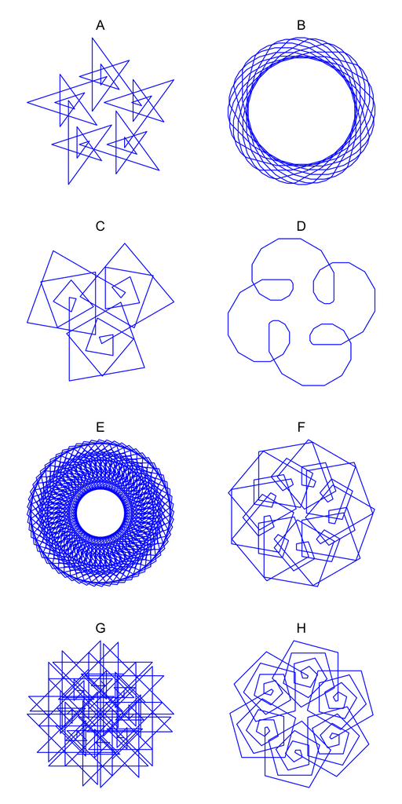

ABCDEFGH

The correct answer is D.

Below I've listed the parameters used to generate all patterns:

- A:
  - Turn angle = 144
  - Count max = 8

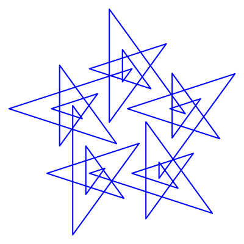

- B:
  - Turn angle = 15
  - Count max = 11

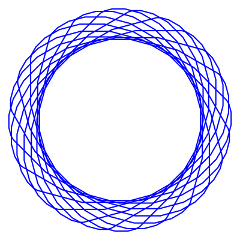

- C:
  - Turn angle = 100
  - Count max = 12

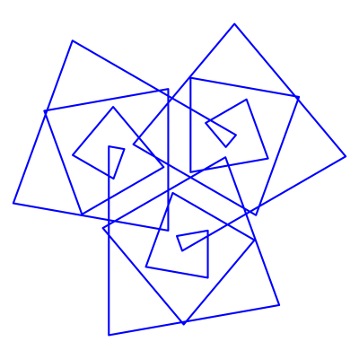

- D:
  - Turn angle = 30
  - Count max = 15

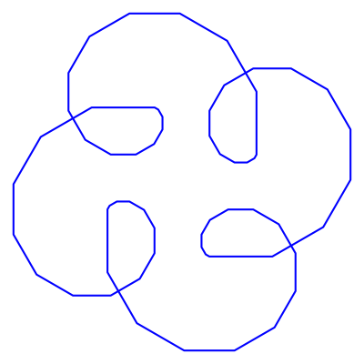

- E:
  - Turn angle = 66
  - Count max = 17

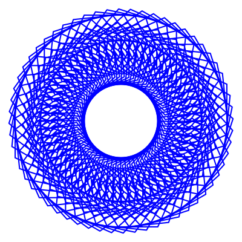

- F:
  - Turn angle = 80
  - Count max = 10

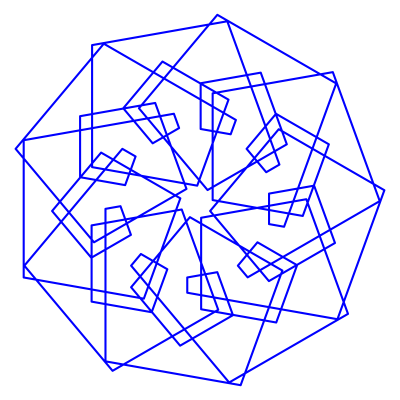

- G:
  - Turn angle = 135
  - Count max = 15

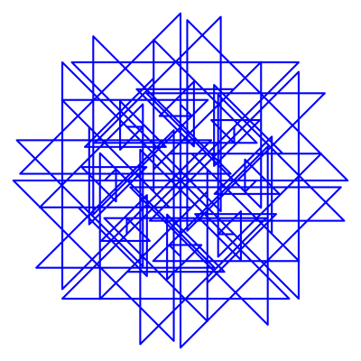

- H:
  - Turn angle = 75
  - Count max = 20

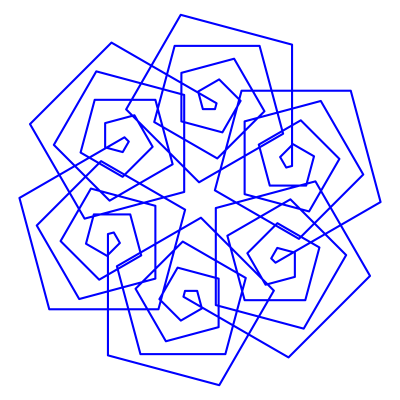

Consider the [L system](https://en.wikipedia.org/wiki/L-system) defined by the following start and replacement rules:

- Start = M
- Rules:
  - K $\to$ QQMM
  - M $\to$ YMK
  - Q $\to$ YYK
  - Y $\to$ MY

After 4 iterations, what string is developed? I'd recommend using [this tool](https://chadworley.github.io/Lsys_string_gen.html).

Consider the [L system](https://en.wikipedia.org/wiki/L-system) defined by the following start and replacement rules:

- Start = YE
- Rules:
  - E $\to$ EESE
  - S $\to$ ES
  - X $\to$ XYX
  - Y $\to$ XESY

After 3 iterations, what string is developed? I'd recommend using [this tool](https://chadworley.github.io/Lsys_string_gen.html).

Consider the [L system](https://en.wikipedia.org/wiki/L-system) defined by the following start and replacement rules:

- Start = FFM
- Rules:
  - D $\to$ FMM
  - F $\to$ DDMF
  - M $\to$ FD

After 3 iterations, what string is developed? I'd recommend using [this tool](https://chadworley.github.io/Lsys_string_gen.html).

Consider the [L system](https://en.wikipedia.org/wiki/L-system) defined by the following start and replacement rules:

- Start = AZR
- Rules:
  - A $\to$ RAZ
  - R $\to$ AR
  - Z $\to$ RA

After 3 iterations, what string is developed? I'd recommend using [this tool](https://chadworley.github.io/Lsys_string_gen.html).

Consider the $L$-system (and angle) defined below:

- Start: `A`
- Rules:  
  `A > A[-BC][+BC]BC`  
  `B > BB[-ABC][+ABC]`  
  `C > CCC[-CBA][+CBA]`
- Number of recursions (number of iterations):
  - 4
- Angle
  - 60°

Please use [this online tool](https://draemm.li/various/fractals/l-systems/) to generate the pattern using "turtle graphics".

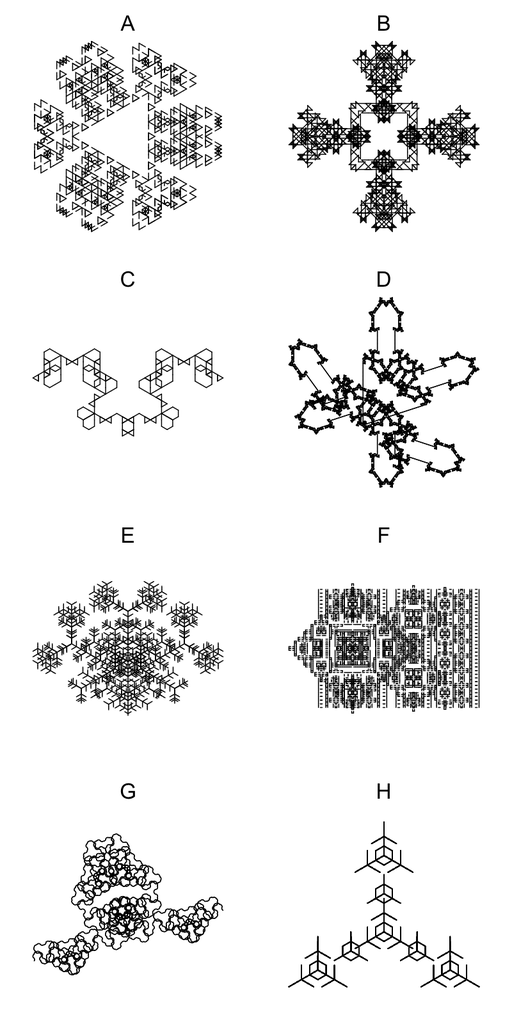

ABCDEFGH

The correct pattern is pattern E.

1. Use the first link: https://draemm.li/various/fractals/l-systems/
2. Copy/paste the `Start`, `Rules`, `Angle`, and `Recursions`.
3. I usually start `Distance` at 1. It can be less than 1, like 0.1, if needed.
4. Click `Run!`
5. If necessary to make the pattern centered and scaled, adjust the `Start pos`, `Start angle`, and `Distance`.
6. Back to the quiz, select the matching pattern.

In case you're interested in the parameters of the other patterns shown:

## Pattern A

- Start: `A-A-A`
- Rules:  
  `A > +B-A+X+A-B+`  
  `B > -BA+BAXAB+AB-`  
  `X > XX`
- Number of recursions (number of iterations):
  - 4
- Angle
  - 120

## Pattern B

- Start: `A++A++A++A`
- Rules:  
  `A > B-ABA-B`  
  `B > A+BB+A`
- Number of recursions (number of iterations):
  - 4
- Angle
  - 135

## Pattern C

- Start: `A`
- Rules:  
  `A > A--B--A`  
  `B > B+C+B`  
  `C > CA+AC`
- Number of recursions (number of iterations):
  - 5
- Angle
  - 60

## Pattern D

- Start: `A`
- Rules:  
  `A > +B-ACA-ACA-B+`  
  `B > -A+BCB+BCB+A-`  
  `C > CCC`
- Number of recursions (number of iterations):
  - 5
- Angle
  - 108

## Pattern E

- Start: `A`
- Rules:  
  `A > A[-BC][+BC]BC`  
  `B > BB[-ABC][+ABC]`  
  `C > CCC[-CBA][+CBA]`
- Number of recursions (number of iterations):
  - 4
- Angle
  - 60

## Pattern F

- Start: `A`
- Rules:  
  `A > +BX-AA-XB+`  
  `B > -AXB+B+BXA-`  
  `X > XX`
- Number of recursions (number of iterations):
  - 6
- Angle
  - 90

## Pattern G

- Start: `A`
- Rules:  
  `A > +B-AA-AA-B+`  
  `B > -A+BB+BB+A-`
- Number of recursions (number of iterations):
  - 5
- Angle
  - 30

## Pattern H

- Start: `B`
- Rules:  
  `A > [+DBC][-DBC][+++DBC]`  
  `B > [-BA][+BA]`  
  `C > AB`  
  `D > XX`  
  `X > XX`
- Number of recursions (number of iterations):
  - 6
- Angle
  - 120

Consider the $L$-system (and angle) defined below:

- Start: `A++A++A++A`
- Rules:  
  `A > B-CAC-B`  
  `B > AB-BA`  
  `C > CC`
- Number of recursions (number of iterations):
  - 5
- Angle
  - 135°

Please use [this online tool](https://draemm.li/various/fractals/l-systems/) to generate the pattern using "turtle graphics".

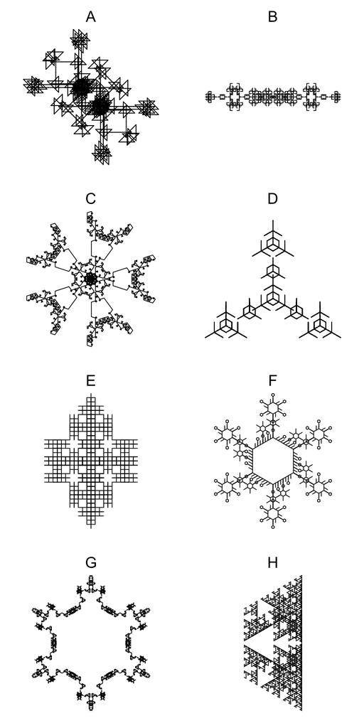

ABCDEFGH

The correct pattern is pattern A.

1. Use the first link: https://draemm.li/various/fractals/l-systems/
2. Copy/paste the `Start`, `Rules`, `Angle`, and `Recursions`.
3. I usually start `Distance` at 1. It can be less than 1, like 0.1, if needed.
4. Click `Run!`
5. If necessary to make the pattern centered and scaled, adjust the `Start pos`, `Start angle`, and `Distance`.
6. Back to the quiz, select the matching pattern.

In case you're interested in the parameters of the other patterns shown:

## Pattern A

- Start: `A++A++A++A`
- Rules:  
  `A > B-CAC-B`  
  `B > AB-BA`  
  `C > CC`
- Number of recursions (number of iterations):
  - 5
- Angle
  - 135

## Pattern B

- Start: `AA`
- Rules:  
  `A > +B-A+X+A-B+`  
  `B > -BA+BAXAB+AB-`  
  `X > XX`
- Number of recursions (number of iterations):
  - 4
- Angle
  - 90

## Pattern C

- Start: `AAAAA`
- Rules:  
  `A > B--A--B`  
  `B > A+BCB+A`  
  `C > CC`
- Number of recursions (number of iterations):
  - 5
- Angle
  - 72

## Pattern D

- Start: `B`
- Rules:  
  `A > [+DBC][-DBC][+++DBC]`  
  `B > [-BA][+BA]`  
  `C > AB`  
  `D > XX`  
  `X > XX`
- Number of recursions (number of iterations):
  - 6
- Angle
  - 120

## Pattern E

- Start: `A`
- Rules:  
  `A > ABA`  
  `B > [-BAB][+BAB]`
- Number of recursions (number of iterations):
  - 6
- Angle
  - 90

## Pattern F

- Start: `A`
- Rules:  
  `A > -B+B+B+B+B+B`  
  `B > BB[-CCA]`  
  `C > CC`
- Number of recursions (number of iterations):
  - 5
- Angle
  - 60

## Pattern G

- Start: `AAAAAA`
- Rules:  
  `A > +B-AXB---ACA---BXA-B+`  
  `B > -A++BXA+++C+++AXB++A-`  
  `C > CC+CC`  
  `X > ++BAX+C+XAB++`
- Number of recursions (number of iterations):
  - 3
- Angle
  - 60

## Pattern H

- Start: `A`
- Rules:  
  `A > +B-AAA-B+`  
  `B > -A+BBB+A-`
- Number of recursions (number of iterations):
  - 5
- Angle
  - 120

Consider the $L$-system (and angle) defined below:

- Start: `A`
- Rules:  
  `A > X[-A][+A]AA`  
  `X > XX`
- Number of recursions (number of iterations):
  - 5
- Angle
  - 60°

Please use [this online tool](https://draemm.li/various/fractals/l-systems/) to generate the pattern using "turtle graphics".

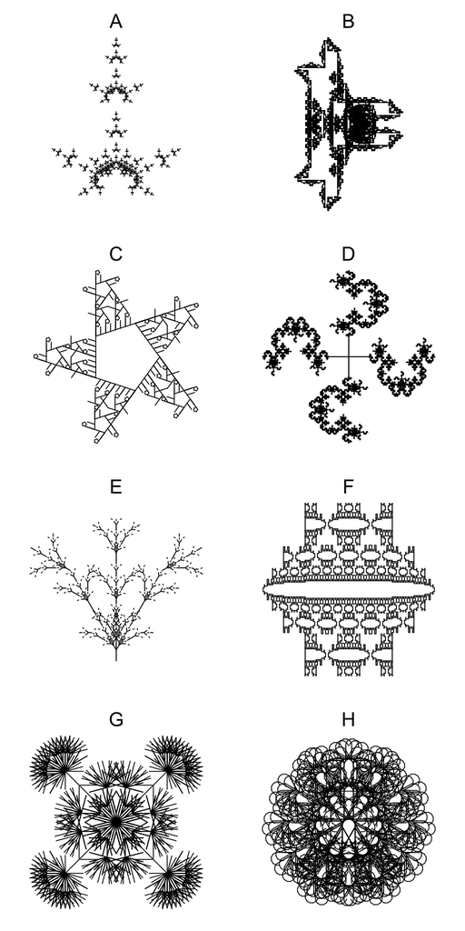

ABCDEFGH

The correct pattern is pattern A.

1. Use the first link: https://draemm.li/various/fractals/l-systems/
2. Copy/paste the `Start`, `Rules`, `Angle`, and `Recursions`.
3. I usually start `Distance` at 1. It can be less than 1, like 0.1, if needed.
4. Click `Run!`
5. If necessary to make the pattern centered and scaled, adjust the `Start pos`, `Start angle`, and `Distance`.
6. Back to the quiz, select the matching pattern.

In case you're interested in the parameters of the other patterns shown:

## Pattern A

- Start: `A`
- Rules:  
  `A > X[-A][+A]AA`  
  `X > XX`
- Number of recursions (number of iterations):
  - 5
- Angle
  - 60

## Pattern B

- Start: `A`
- Rules:  
  `A > A--CBC--A`  
  `B > B+A+B`  
  `C > -CB+BC-`
- Number of recursions (number of iterations):
  - 7
- Angle
  - 90

## Pattern C

- Start: `A`
- Rules:  
  `A > B+B+B+B+B`  
  `B > [-CCA]BB`  
  `C > CC`
- Number of recursions (number of iterations):
  - 5
- Angle
  - 72

## Pattern D

- Start: `A`
- Rules:  
  `A > [-CB][+CB][CB][--CB]`  
  `B > D+B-D-B+D`  
  `C > CC`  
  `D > B-D+A+D-B`
- Number of recursions (number of iterations):
  - 6
- Angle
  - 90

## Pattern E

- Start: `X`
- Rules:  
  `F > FF`  
  `X > FF[+XFFX+XF][-XFFX-XF]FXXFX`
- Number of recursions (number of iterations):
  - 3
- Angle
  - 30

## Pattern F

- Start: `A++A`
- Rules:  
  `A > +B-CAC-B+`  
  `B > -A+BB+A-`  
  `C > CC`
- Number of recursions (number of iterations):
  - 6
- Angle
  - 90

## Pattern G

- Start: `[A]------------[A]`
- Rules:  
  `A > [---BC][+++BC]`  
  `B > [--AC][++AC]`  
  `C > F[-BA][+BA]`  
  `F > FF`
- Number of recursions (number of iterations):
  - 5
- Angle
  - 15

## Pattern H

- Start: `A++++++.A`
- Rules:  
  `A > B+B+B+B+B+B+B`  
  `B > B[-CCA][+CCA]`  
  `C > CC`
- Number of recursions (number of iterations):
  - 5
- Angle
  - 30

Consider the $L$-system (and angle) defined below:

- Start: `AA`
- Rules:  
  `A > C--AA+B+AA--C`  
  `B > BA+C+AB`  
  `C > -B-CA++AC-B-`
- Number of recursions (number of iterations):
  - 4
- Angle
  - 30°

Please use [this online tool](https://draemm.li/various/fractals/l-systems/) to generate the pattern using "turtle graphics".

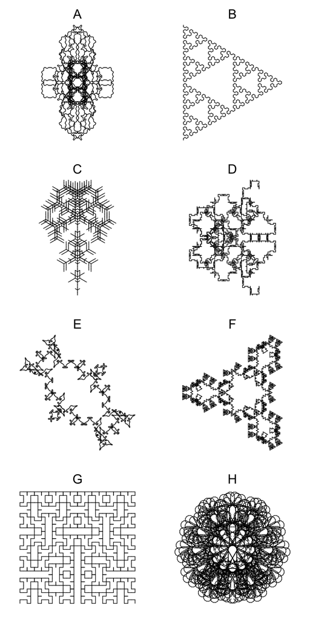

ABCDEFGH

The correct pattern is pattern A.

1. Use the first link: https://draemm.li/various/fractals/l-systems/
2. Copy/paste the `Start`, `Rules`, `Angle`, and `Recursions`.
3. I usually start `Distance` at 1. It can be less than 1, like 0.1, if needed.
4. Click `Run!`
5. If necessary to make the pattern centered and scaled, adjust the `Start pos`, `Start angle`, and `Distance`.
6. Back to the quiz, select the matching pattern.

In case you're interested in the parameters of the other patterns shown:

## Pattern A

- Start: `AA`
- Rules:  
  `A > C--AA+B+AA--C`  
  `B > BA+C+AB`  
  `C > -B-CA++AC-B-`
- Number of recursions (number of iterations):
  - 4
- Angle
  - 30

## Pattern B

- Start: `A`
- Rules:  
  `A > B-A-B`  
  `B > A+B+A`
- Number of recursions (number of iterations):
  - 6
- Angle
  - 60

## Pattern C

- Start: `A`
- Rules:  
  `A > AA[-B][+B]B`  
  `B > B[-ABC][+ABC]`  
  `C > C[-CBA][+CBA]`
- Number of recursions (number of iterations):
  - 4
- Angle
  - 60

## Pattern D

- Start: `A`
- Rules:  
  `A > +BA+A-ABA-A+AB+`  
  `B > +BA-B--B-AB+`
- Number of recursions (number of iterations):
  - 4
- Angle
  - 90

## Pattern E

- Start: `BABA`
- Rules:  
  `A > +BA+A-ABBA-A+AB+`  
  `B > +BBA-B--B-ABB+`
- Number of recursions (number of iterations):
  - 3
- Angle
  - 45

## Pattern F

- Start: `CCC`
- Rules:  
  `A > C--ABA--C`  
  `B > B+C+B`  
  `C > -CA+AC-`
- Number of recursions (number of iterations):
  - 5
- Angle
  - 120

## Pattern G

- Start: `-A`
- Rules:  
  `A > +B-AA-B+`  
  `B > -A+BB+A-`
- Number of recursions (number of iterations):
  - 5
- Angle
  - 90

## Pattern H

- Start: `A++++++.A`
- Rules:  
  `A > B+B+B+B+B+B+B`  
  `B > B[-CCA][+CCA]`  
  `C > CC`
- Number of recursions (number of iterations):
  - 5
- Angle
  - 30